# Text Mining In R Introduction

Saumya Mehta

5/14/2018

## Tidy text (R package)

Treating text as dataframes allows us to visualize, manipulate and summarise the characteristics of text easily and integrate natural language processing into our workflows.

## Tidy text format

Tidy data has a specific structure:  
* Each Variable is a column. * Each observation is a row. * Each type of observational unit is a table.  
Table with one token per row. Token is a meaningful unit of text which we are interested in using for analysis. Token can be a word, n-gram, sentence or a paragraph. Tidytext package can convert to one term per row format. Keep input and output in tidy tables. Package includes functions to tidy the data if data is not in tidy format. After applying dplyr and other functions, converted to document-term matrix for machine learning applications. Models can be reconverted into tidy format for analysis and visualization.

## unnest_tokens function

```r
text <- c("Because I could not stop for Death -",
          "He kindly stopped for me -",
          "The Carriage held but just Ourselves -",
          "and Immortality")
library(dplyr)
text_df <- data_frame(line = 1:4, text = text)
text_df
```

```
## # A tibble: 4 x 2
##    line text
##   <int> <chr>
## 1     1 Because I could not stop for Death -
## 2     2 He kindly stopped for me -
## 3     3 The Carriage held but just Ourselves -
## 4     4 and Immortality
```

This prints out a tibble. It will not convert string to factors and doesn’t use row names. Now we need to convert text_df into one term per row format. Break the text into tokens and then transform into tidy structure. It is done by unnest_tokens().

```r
library(tidytext)
text_df %>%
  unnest_tokens(word,text)
```

```
## # A tibble: 20 x 2
##     line word
##    <int> <chr>
##  1     1 because
##  2     1 i
##  3     1 could
##  4     1 not
##  5     1 stop
##  6     1 for
##  7     1 death
##  8     2 he
##  9     2 kindly
## 10     2 stopped
## 11     2 for
## 12     2 me
## 13     3 the
## 14     3 carriage
## 15     3 held
## 16     3 but
## 17     3 just
## 18     3 ourselves
## 19     4 and
## 20     4 immortality
```

Default tokenization of unnest_tokens is for one word.  
* Other columns such as line number from which word came from is retained. * Punctuation has been stripped. * By default conversion to lower case.

## Example : Tidying works of Jane Austen

janeaustenr package  
Provides text in one row per line format

```r
  library(janeaustenr)
  library(dplyr)
  library(stringr)
  original_books <- austen_books()%>%
    mutate(line_number = row_number(),
           chapter = cumsum(str_detect(text, regex("^chapter [\\divxlc]",ignore_case = T))))%>%
    ungroup()
```

Now, we need to transform into one token per row format using unnest_tokens()

```r
library(tidytext)
tidy_books <- original_books%>%
  unnest_tokens(word,text)
```

This function uses tokenizers package to separate each line in the original text into tokens. Now we need to remove the stop words. Stopwords are kept in dataset stop_words. We can remove them using anti join on the tidy_books.

```r
data("stop_words")
tidy_books <- tidy_books%>%
  anti_join(stop_words)
```

Finding the most common words using count.

```r
tidy_books%>%
  count(word, sort =T)
```

```
## # A tibble: 13,914 x 2
##    word       n
##    <chr>  <int>
##  1 miss    1855
##  2 time    1337
##  3 fanny    862
##  4 dear     822
##  5 lady     817
##  6 sir      806
##  7 day      797
##  8 emma     787
##  9 sister   727
## 10 house    699
## # ... with 13,904 more rows
```

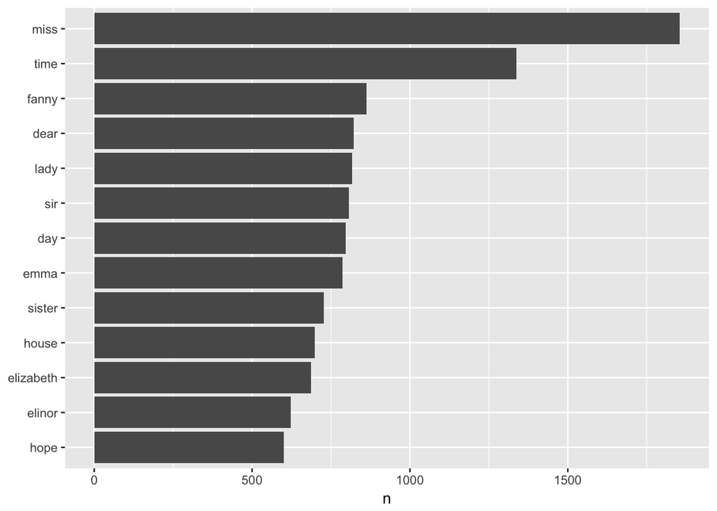

Fig 1.1 Most common words in Austen’s Novels

## Gutenberger package

Package provides access to public domain networks from Project Guttenberg collection. Includes tools for downloading books and complete dataset of Project Guttenberg metadata to be used to find works of interest. gutenberg_download() to download by ID.

## Word Frequencies

```r
library('gutenbergr')
hgwells <- gutenberg_download(c(35,36,5230,159))
```

```
## Determining mirror for Project Gutenberg from http://www.gutenberg.org/robot/harvest
```

```
## Using mirror http://aleph.gutenberg.org
```

```r
tidy_hgwells <- hgwells %>%
  unnest_tokens(word,text) %>%
  anti_join(stop_words)
tidy_hgwells %>%
  count(word, sort = T)
```

```
## # A tibble: 11,769 x 2
##    word       n
##    <chr>  <int>
##  1 time     454
##  2 people   302
##  3 door     260
##  4 heard    249
##  5 black    232
##  6 stood    229
##  7 white    222
##  8 hand     218
##  9 kemp     213
## 10 eyes     210
## # ... with 11,759 more rows
```

# Analysis for bronte

```r
bronte <- gutenberg_download(c(1260, 768, 969, 9182, 767))

tidy_bronte <- bronte %>%
  unnest_tokens(word, text) %>%
  anti_join(stop_words)
tidy_bronte %>%
  count(word, sort = TRUE)
```

```
## # A tibble: 23,050 x 2
##    word       n
##    <chr>  <int>
##  1 time    1065
##  2 miss     855
##  3 day      827
##  4 hand     768
##  5 eyes     713
##  6 night    647
##  7 heart    638
##  8 looked   601
##  9 door     592
## 10 half     586
## # ... with 23,040 more rows
```

Calculating frequencies

```r
library(tidyr)
frequency <- bind_rows(mutate(tidy_bronte, author = 'Bronte Sisters'),
                       mutate(tidy_hgwells, author = 'H.G. Wells'),
                       mutate(tidy_books, author = 'Jane Austen')) %>%
  mutate(word = str_extract(word, "[a-z']+")) %>%
  count(author, word) %>%
  group_by(author) %>%
  mutate(proportion = n/sum(n)) %>%
  select(-n) %>%
  spread(author, proportion) %>%
  gather(author, proportion, `Bronte Sisters`, `H.G. Wells`)
```

Plot for the same

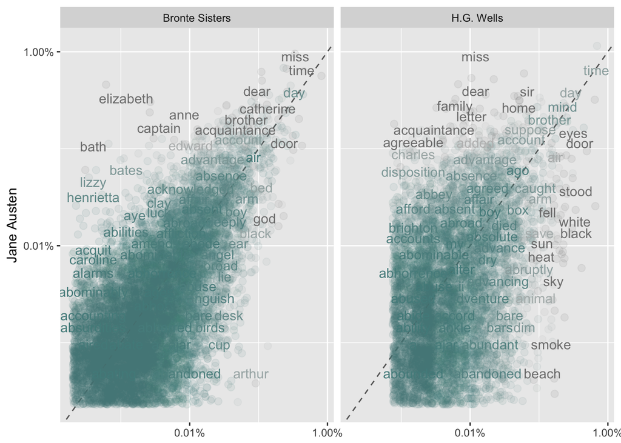

Fig 1.2 Word Proportions in Bronte Sisters and H.G. Wells

- There is more space at lower frequencies at austin wells than at austen bronte. This indicates that austen bronte are more similar than austen wells.
- Correlation test will help us determine how similar the classes are to each other.

```r
cor.test(data = frequency[frequency$author == "H.G. Wells",],
         ~proportion + `Jane Austen`)
```

```
##
##  Pearson's product-moment correlation
##
## data:  proportion and Jane Austen
## t = 36.441, df = 6053, p-value < 2.2e-16
## alternative hypothesis: true correlation is not equal to 0
## 95 percent confidence interval:
##  0.4032800 0.4445987
## sample estimates:
##       cor
## 0.4241601
```

```r
cor.test(data = frequency[frequency$author == "Bronte Sisters",],
         ~proportion + `Jane Austen`)
```

```
##
##  Pearson's product-moment correlation
##
## data:  proportion and Jane Austen
## t = 119.65, df = 10404, p-value < 2.2e-16
## alternative hypothesis: true correlation is not equal to 0
## 95 percent confidence interval:
##  0.7527869 0.7689641
## sample estimates:
##       cor
## 0.7609938
```